# HW 05

#### Author : Sarthak Miglani

#### Data Set : patient_risk_profiles

## Data selection

This dataset contains 100 simulated patient's medical history features and the predicted 1-year risk of 14 outcomes based on each patient's medical history features. The predictions used real logistic regression models developed on a large real world healthcare dataset.

\ Data Dictionary

| variable | class | description |
| --- | --- | --- |
| personId | integer | A unique identifier for the simulated patient |
| age group: 10 - 14 | integer | A binary column where 1 means the patient is aged between 10-14 (inclusive) and 0 means the patient is not in that age group |
| age group: 15 - 19 | integer | A binary column where 1 means the patient is aged between 15-19 (inclusive) and 0 means the patient is not in that age group |
| age group: 20 - 24 | integer | A binary column where 1 means the patient is aged between 20-24 (inclusive) and 0 means the patient is not in that age group |
| age group: 65 - 69 | integer | A binary column where 1 means the patient is aged between 65-69 (inclusive) and 0 means the patient is not in that age group |
| age group: 40 - 44 | integer | A binary column where 1 means the patient is aged between 40-44 (inclusive) and 0 means the patient is not in that age group |
| age group: 45 - 49 | integer | A binary column where 1 means the patient is aged between 45-49 (inclusive) and 0 means the patient is not in that age group |
| age group: 55 - 59 | integer | A binary column where 1 means the patient is aged between 55-59 (inclusive) and 0 means the patient is not in that age group |
| age group: 85 - 89 | integer | A binary column where 1 means the patient is aged between 85-89 (inclusive) and 0 means the patient is not in that age group |
| age group: 75 - 79 | integer | A binary column where 1 means the patient is aged between 75-79 (inclusive) and 0 means the patient is not in that age group |
| age group: 5 - 9 | integer | A binary column where 1 means the patient is aged between 5-9 (inclusive) and 0 means the patient is not in that age group |
| age group: 25 - 29 | integer | A binary column where 1 means the patient is aged between 25-29 (inclusive) and 0 means the patient is not in that age group |
| age group: 0 - 4 | integer | A binary column where 1 means the patient is aged between 0-4 (inclusive) and 0 means the patient is not in that age group |
| age group: 70 - 74 | integer | A binary column where 1 means the patient is aged between 70-74 (inclusive) and 0 means the patient is not in that age group |
| age group: 50 - 54 | integer | A binary column where 1 means the patient is aged between 50-54 (inclusive) and 0 means the patient is not in that age group |
| age group: 60 - 64 | integer | A binary column where 1 means the patient is aged between 60-64 (inclusive) and 0 means the patient is not in that age group |
| age group: 35 - 39 | integer | A binary column where 1 means the patient is aged between 35-39 (inclusive) and 0 means the patient is not in that age group |
| age group: 30 - 34 | integer | A binary column where 1 means the patient is aged between 30-34 (inclusive) and 0 means the patient is not in that age group |
| age group: 80 - 84 | integer | A binary column where 1 means the patient is aged between 80-84 (inclusive) and 0 means the patient is not in that age group |
| age group: 90 - 94 | integer | A binary column where 1 means the patient is aged between 90-94 (inclusive) and 0 means the patient is not in that age group |
| Sex = FEMALE | integer | A binary column where 1 means the patient has a female sex |
| sex = MALE | integer | A binary column where 1 means the patient has a male sex |
| Acetaminophen exposures in prior year | integer | A binary column where 1 means the patient had a record for acetaminophen in the prior year and 0 means they did not |
| Occurrence of Alcoholism in prior year | integer | A binary column where 1 means the patient had a record for alcoholism in the prior year and 0 means they did not |
| Anemia in prior year | integer | A binary column where 1 means the patient had a record for anemia in the prior year and 0 means they did not |
| Angina events in prior year | integer | A binary column where 1 means the patient had a record for angina in the prior year and 0 means they did not |
| ANTIEPILEPTICS in prior year | integer | A binary column where 1 means the patient had a record for a drug in the category ANTIEPILEPTICS in the prior year and 0 means they did not |
| Occurrence of Anxiety in prior year | integer | A binary column where 1 means the patient had a record for anxiety in the prior year and 0 means they did not |
| Osteoarthritis in prior year | integer | A binary column where 1 means the patient had a record for osteoarthritis in the prior year and 0 means they did not |
| Aspirin exposures in prior year | integer | A binary column where 1 means the patient had a record for aspirin in the prior year and 0 means they did not |

[output cut: 70 more lines]

```python
#Importing Libraries
import pandas as pd
import numpy as np
import matplotlib.pyplot as plt
import re
import statsmodels.api as sm
import seaborn as sns
from scipy import stats
from sklearn.preprocessing import LabelEncoder
from sklearn.decomposition import PCA
from sklearn.model_selection import train_test_split
from sklearn.model_selection import cross_val_score
from sklearn.linear_model import LinearRegression
from sklearn.ensemble import RandomForestRegressor
from sklearn.linear_model import LogisticRegression
from sklearn.model_selection import GridSearchCV
from sklearn.metrics import r2_score, mean_squared_error, mean_absolute_error
```

```python
data1 = pd.read_csv('https://raw.githubusercontent.com/rfordatascience/tidytuesday/master/data/2023/2023-10-24/patient_risk_profiles.csv', header='infer')
data1
```

|  | personId | age group: 10 - 14 | age group: 15 - 19 | age group: 20 - 24 | age group: 65 - 69 | age group: 40 - 44 | age group: 45 - 49 | age group: 55 - 59 | age group: 85 - 89 | age group: 75 - 79 | ... | predicted risk of Muscle weakness or injury | predicted risk of Ankylosing Spondylitis | predicted risk of Autoimmune hepatitis | predicted risk of Multiple Sclerosis | predicted risk of Acute pancreatitis, with No chronic or hereditary or common causes of pancreatitis | predicted risk of Ulcerative colitis | predicted risk of Migraine | predicted risk of Dementia | predicted risk of Treatment resistant depression (TRD) | predicted risk of Parkinson's disease, inpatient or with 2nd diagnosis |
| --- | --- | --- | --- | --- | --- | --- | --- | --- | --- | --- | --- | --- | --- | --- | --- | --- | --- | --- | --- | --- | --- |
| 0 | 1 | 0 | 0 | 0 | 0 | 0 | 0 | 0 | 0 | 0 | ... | 0.018832 | 0.000076 | 0.000080 | 0.000469 | 0.000124 | 0.000231 | 0.006544 | 0.000073 | 0.000394 | 0.000040 |
| 1 | 2 | 0 | 0 | 0 | 0 | 0 | 0 | 0 | 0 | 0 | ... | 0.179579 | 0.000502 | 0.000008 | 0.000421 | 0.000817 | 0.001567 | 0.024364 | 0.283879 | 0.013889 | 0.019553 |
| 2 | 3 | 0 | 0 | 0 | 0 | 0 | 1 | 0 | 0 | 0 | ... | 0.022318 | 0.000462 | 0.000023 | 0.000527 | 0.000417 | 0.001275 | 0.005430 | 0.001282 | 0.001017 | 0.000113 |
| 3 | 4 | 0 | 0 | 0 | 0 | 0 | 0 | 0 | 0 | 0 | ... | 0.022062 | 0.000482 | 0.000034 | 0.000911 | 0.000236 | 0.006386 | 0.006637 | 0.000707 | 0.002266 | 0.000041 |
| 4 | 5 | 0 | 0 | 0 | 0 | 0 | 0 | 0 | 0 | 0 | ... | 0.063311 | 0.004115 | 0.000083 | 0.001859 | 0.000700 | 0.062065 | 0.004683 | 0.016372 | 0.000056 | 0.003312 |
| ... | ... | ... | ... | ... | ... | ... | ... | ... | ... | ... | ... | ... | ... | ... | ... | ... | ... | ... | ... | ... | ... |
| 95 | 96 | 0 | 0 | 0 | 0 | 0 | 0 | 0 | 0 | 0 | ... | 0.018149 | 0.000411 | 0.000041 | 0.000423 | 0.000388 | 0.001664 | 0.012047 | 0.001152 | 0.001375 | 0.000154 |
| 96 | 97 | 0 | 0 | 0 | 0 | 0 | 0 | 0 | 0 | 0 | ... | 0.008068 | 0.000520 | 0.000011 | 0.000036 | 0.000089 | 0.000385 | 0.000700 | 0.000016 | 0.000191 | 0.000030 |
| 97 | 98 | 0 | 0 | 0 | 0 | 0 | 0 | 0 | 0 | 0 | ... | 0.217159 | 0.001261 | 0.000092 | 0.000219 | 0.002008 | 0.002333 | 0.000461 | 0.303624 | 0.000485 | 0.002572 |
| 98 | 99 | 0 | 0 | 0 | 0 | 0 | 0 | 0 | 1 | 0 | ... | 0.056540 | 0.001541 | 0.000046 | 0.000192 | 0.000317 | 0.001371 | 0.002193 | 0.047227 | 0.000403 | 0.001963 |
| 99 | 100 | 0 | 0 | 0 | 0 | 0 | 0 | 0 | 0 | 0 | ... | 0.126297 | 0.000594 | 0.000021 | 0.000703 | 0.001218 | 0.005166 | 0.003479 | 0.105997 | 0.001579 | 0.006170 |

100 rows × 100 columns

## Question

### **Can we predict the risk of Dementia based on other factors?**

## Visualization

Average Risk of Dementia by Age Group

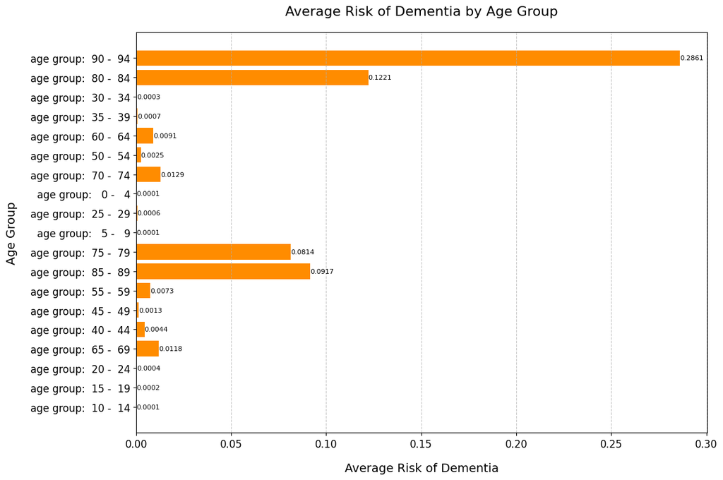

```python
# Extracting the relevant columns for age groups and dementia risk
age_group_columns = [col for col in data1.columns if col.startswith('age group:')]
age_group_data = data1[age_group_columns]
dementia_risk = data1['predicted risk of Dementia']

# Preparing the data for the plot
# Summing up the number of people in each age group
age_group_totals = age_group_data.sum()

# Calculating the average risk of dementia for each age group
average_risk_per_age_group = {}
for col in age_group_columns:
    # Getting the indices where the age group is 1 (i.e., the patient belongs to that age group)
    indices = age_group_data[age_group_data[col] == 1].index
    # Calculating the average risk for this age group
    average_risk_per_age_group[col] = dementia_risk[indices].mean()

# Converting to a format suitable for plotting
age_groups = list(average_risk_per_age_group.keys())
average_risks = list(average_risk_per_age_group.values())

# Creating a horizontal bar plot for average risk of dementia by age group

plt.figure(figsize=(12, 8))

# Plotting horizontal bars
plt.barh(age_groups, average_risks, color='darkorange')

# Adding labels to each bar for clarity
for index, value in enumerate(average_risks):
    plt.text(value, index, f'{value:.4f}', va='center', ha='left', fontsize=8)

# Enhancing the overall graph aesthetics
plt.ylabel('Age Group', fontsize=14, labelpad=15)
plt.xlabel('Average Risk of Dementia', fontsize=14, labelpad=15)
plt.title('Average Risk of Dementia by Age Group', fontsize=16, pad=20)
plt.yticks(fontsize=12)
plt.xticks(fontsize=12)
plt.grid(axis='x', linestyle='--', alpha=0.7)
plt.tight_layout()

plt.show()
```

The horizontal bar plot visualizes the average risk of dementia for various age groups. Each bar length represents the magnitude of risk, with annotated values offering precise risk percentages. The age group "90 - 94" has the highest average risk at approximately 0.2861, indicating a strong correlation between advancing age and the risk of developing dementia. In contrast, younger age groups exhibit significantly lower risks, with values close to 0. The data underscore the increased average risk associated with older age groups, emphasizing the need for age-specific approaches to dementia risk assessment and intervention.

## Data Exploration

Cleaning up the dataset by removing specific columns that are not necessary for the analysis.

```python
columns_to_drop = ["predicted risk of  Treatment resistant depression (TRD)", "predicted risk of Parkinson's disease, inpatient or with 2nd diagnosis", 'predicted risk of Sudden Vision Loss, with no eye pathology causes', 'predicted risk of Sudden Hearing Loss, No congenital anomaly or middle or inner ear conditions', 'predicted risk of Pulmonary Embolism', 'predicted risk of Restless Leg Syndrome', 'predicted risk of Muscle weakness or injury', 'predicted risk of Ankylosing Spondylitis', 'predicted risk of Autoimmune hepatitis', 'predicted risk of Multiple Sclerosis', 'predicted risk of Acute pancreatitis, with No chronic or hereditary or common causes of pancreatitis', 'predicted risk of Ulcerative colitis', 'predicted risk of Migraine']
data = data1.drop(columns_to_drop, axis=1)
data
```

|  | personId | age group: 10 - 14 | age group: 15 - 19 | age group: 20 - 24 | age group: 65 - 69 | age group: 40 - 44 | age group: 45 - 49 | age group: 55 - 59 | age group: 85 - 89 | age group: 75 - 79 | ... | Antibiotics Macrolides in prior year | Antibiotics Monobactams in prior year | Antibiotics Oxazolidinones in prior year | Antibiotics Penicillins in prior year | Antibiotics Polypeptides in prior year | Antibiotics Rifamycins in prior year | Antibiotics Sulfonamides in prior year | Antibiotics Streptogramins in prior year | Antibiotics Tetracyclines in prior year | predicted risk of Dementia |
| --- | --- | --- | --- | --- | --- | --- | --- | --- | --- | --- | --- | --- | --- | --- | --- | --- | --- | --- | --- | --- | --- |
| 0 | 1 | 0 | 0 | 0 | 0 | 0 | 0 | 0 | 0 | 0 | ... | 0 | 1 | 0 | 0 | 0 | 0 | 0 | 0 | 0 | 0.000073 |
| 1 | 2 | 0 | 0 | 0 | 0 | 0 | 0 | 0 | 0 | 0 | ... | 0 | 1 | 0 | 0 | 0 | 1 | 0 | 0 | 1 | 0.283879 |
| 2 | 3 | 0 | 0 | 0 | 0 | 0 | 1 | 0 | 0 | 0 | ... | 0 | 0 | 0 | 0 | 1 | 0 | 0 | 0 | 0 | 0.001282 |
| 3 | 4 | 0 | 0 | 0 | 0 | 0 | 0 | 0 | 0 | 0 | ... | 0 | 0 | 1 | 0 | 0 | 0 | 1 | 1 | 1 | 0.000707 |
| 4 | 5 | 0 | 0 | 0 | 0 | 0 | 0 | 0 | 0 | 0 | ... | 1 | 0 | 0 | 0 | 0 | 0 | 0 | 1 | 0 | 0.016372 |
| ... | ... | ... | ... | ... | ... | ... | ... | ... | ... | ... | ... | ... | ... | ... | ... | ... | ... | ... | ... | ... | ... |
| 95 | 96 | 0 | 0 | 0 | 0 | 0 | 0 | 0 | 0 | 0 | ... | 0 | 0 | 0 | 0 | 0 | 0 | 0 | 1 | 1 | 0.001152 |
| 96 | 97 | 0 | 0 | 0 | 0 | 0 | 0 | 0 | 0 | 0 | ... | 0 | 0 | 1 | 0 | 0 | 1 | 0 | 0 | 0 | 0.000016 |
| 97 | 98 | 0 | 0 | 0 | 0 | 0 | 0 | 0 | 0 | 0 | ... | 0 | 1 | 1 | 0 | 1 | 0 | 0 | 0 | 0 | 0.303624 |
| 98 | 99 | 0 | 0 | 0 | 0 | 0 | 0 | 0 | 1 | 0 | ... | 0 | 0 | 0 | 1 | 0 | 0 | 0 | 1 | 0 | 0.047227 |
| 99 | 100 | 0 | 0 | 0 | 0 | 0 | 0 | 0 | 0 | 0 | ... | 0 | 0 | 0 | 1 | 0 | 1 | 0 | 0 | 0 | 0.105997 |

100 rows × 87 columns

```python
# Assuming patient_risk_profiles is your DataFrame
data.columns = data.columns.str.replace(' ', '_').str.lower()

# Pivoting 'age_group' columns
age_group_cols = [col for col in data.columns if 'age_group' in col]
df_age_group = data.melt(id_vars=[col for col in data.columns if col not in age_group_cols],
                                          value_vars=age_group_cols,
                                          var_name='ageGroup',
                                          value_name='ageCount')

# Pivoting 'sex' columns
sex_cols = [col for col in df_age_group.columns if 'sex' in col]
data = df_age_group.melt(id_vars=[col for col in df_age_group.columns if col not in sex_cols],
                           value_vars=sex_cols,
                           var_name='sex',
                           value_name='sexCount')

# Cleaning up the column values
data['ageGroup'] = data['ageGroup'].apply(lambda x: re.sub('age_group_', '', x))
data['sex'] = data['sex'].apply(lambda x: re.sub('sex_', '', x))
data
```

|  | personid | acetaminophen_exposures_in_prior_year | occurrence_of_alcoholism_in_prior_year | anemia_in_prior_year | angina_events_in_prior_year | antiepileptics_in_prior_year | occurrence_of_anxiety_in_prior_year | osteoarthritis_in_prior_year | aspirin_exposures_in_prior_year | occurrence_of_asthma_in_prior_year | ... | antibiotics_polypeptides_in_prior_year | antibiotics_rifamycins_in_prior_year | antibiotics_sulfonamides_in_prior_year | antibiotics_streptogramins_in_prior_year | antibiotics_tetracyclines_in_prior_year | predicted_risk_of_dementia | ageGroup | ageCount | sex | sexCount |
| --- | --- | --- | --- | --- | --- | --- | --- | --- | --- | --- | --- | --- | --- | --- | --- | --- | --- | --- | --- | --- | --- |
| 0 | 1 | 1 | 0 | 0 | 1 | 1 | 0 | 1 | 0 | 0 | ... | 0 | 0 | 0 | 0 | 0 | 0.000073 | age_group:__10_-__14 | 0 | =_female | 1 |
| 1 | 2 | 0 | 0 | 0 | 0 | 1 | 0 | 0 | 0 | 1 | ... | 0 | 1 | 0 | 0 | 1 | 0.283879 | age_group:__10_-__14 | 0 | =_female | 0 |
| 2 | 3 | 0 | 0 | 0 | 0 | 0 | 0 | 0 | 0 | 0 | ... | 1 | 0 | 0 | 0 | 0 | 0.001282 | age_group:__10_-__14 | 0 | =_female | 0 |
| 3 | 4 | 0 | 0 | 0 | 0 | 0 | 1 | 0 | 1 | 0 | ... | 0 | 0 | 1 | 1 | 1 | 0.000707 | age_group:__10_-__14 | 0 | =_female | 0 |
| 4 | 5 | 0 | 0 | 1 | 0 | 1 | 0 | 0 | 0 | 0 | ... | 0 | 0 | 0 | 1 | 0 | 0.016372 | age_group:__10_-__14 | 0 | =_female | 1 |
| ... | ... | ... | ... | ... | ... | ... | ... | ... | ... | ... | ... | ... | ... | ... | ... | ... | ... | ... | ... | ... | ... |
| 3795 | 96 | 0 | 0 | 0 | 0 | 0 | 0 | 0 | 0 | 1 | ... | 0 | 0 | 0 | 1 | 1 | 0.001152 | age_group:__90_-__94 | 0 | =_male | 0 |
| 3796 | 97 | 0 | 1 | 0 | 0 | 0 | 0 | 0 | 0 | 0 | ... | 0 | 1 | 0 | 0 | 0 | 0.000016 | age_group:__90_-__94 | 0 | =_male | 1 |
| 3797 | 98 | 0 | 0 | 0 | 0 | 0 | 0 | 1 | 0 | 0 | ... | 1 | 0 | 0 | 0 | 0 | 0.303624 | age_group:__90_-__94 | 1 | =_male | 1 |
| 3798 | 99 | 0 | 0 | 0 | 0 | 0 | 0 | 1 | 0 | 0 | ... | 0 | 0 | 0 | 1 | 0 | 0.047227 | age_group:__90_-__94 | 0 | =_male | 1 |
| 3799 | 100 | 0 | 0 | 1 | 1 | 1 | 0 | 0 | 0 | 0 | ... | 0 | 1 | 0 | 0 | 0 | 0.105997 | age_group:__90_-__94 | 0 | =_male | 1 |

3800 rows × 70 columns

### Missing Values:

```python
# Checking for missing values in the new dataset
missing_values_new = data.isnull().sum()
missing_values_new
```

```
personid                                  0
acetaminophen_exposures_in_prior_year     0
occurrence_of_alcoholism_in_prior_year    0
anemia_in_prior_year                      0
angina_events_in_prior_year               0
                                         ..
predicted_risk_of_dementia                0
ageGroup                                  0
ageCount                                  0
sex                                       0
sexCount                                  0
Length: 70, dtype: int64
```

### Outliers and Data Distribution:

- The statistical summary suggests varied distributions across different variables.
- The predicted risk of Dementia column, our primary variable of interest, shows a wide range in its values (minimum of 0.000013, maximum of 0.414668), indicating variability in dementia risk among the patients.
- Some columns, particularly those related to age groups and antibiotic use, show a high proportion of 0 values, which is expected given their categorical nature.

```python
# Identifying outliers using statistical summary for the new dataset
statistical_summary_new = data.describe()
statistical_summary_new
```

|  | personid | acetaminophen_exposures_in_prior_year | occurrence_of_alcoholism_in_prior_year | anemia_in_prior_year | angina_events_in_prior_year | antiepileptics_in_prior_year | occurrence_of_anxiety_in_prior_year | osteoarthritis_in_prior_year | aspirin_exposures_in_prior_year | occurrence_of_asthma_in_prior_year | ... | antibiotics_oxazolidinones_in_prior_year | antibiotics_penicillins_in_prior_year | antibiotics_polypeptides_in_prior_year | antibiotics_rifamycins_in_prior_year | antibiotics_sulfonamides_in_prior_year | antibiotics_streptogramins_in_prior_year | antibiotics_tetracyclines_in_prior_year | predicted_risk_of_dementia | ageCount | sexCount |
| --- | --- | --- | --- | --- | --- | --- | --- | --- | --- | --- | --- | --- | --- | --- | --- | --- | --- | --- | --- | --- | --- |
| count | 3800.000000 | 3800.000000 | 3800.000000 | 3800.000000 | 3800.000000 | 3800.000000 | 3800.000000 | 3800.000000 | 3800.000000 | 3800.000000 | ... | 3800.000000 | 3800.000000 | 3800.000000 | 3800.000000 | 3800.000000 | 3800.000000 | 3800.000000 | 3800.000000 | 3800.000000 | 3800.000000 |
| mean | 50.500000 | 0.080000 | 0.120000 | 0.180000 | 0.130000 | 0.150000 | 0.100000 | 0.180000 | 0.170000 | 0.150000 | ... | 0.180000 | 0.150000 | 0.160000 | 0.200000 | 0.190000 | 0.160000 | 0.090000 | 0.028545 | 0.052632 | 0.545000 |
| std | 28.869869 | 0.271329 | 0.325004 | 0.384238 | 0.336348 | 0.357118 | 0.300039 | 0.384238 | 0.375682 | 0.357118 | ... | 0.384238 | 0.357118 | 0.366654 | 0.400053 | 0.392353 | 0.366654 | 0.286219 | 0.071585 | 0.223326 | 0.498036 |
| min | 1.000000 | 0.000000 | 0.000000 | 0.000000 | 0.000000 | 0.000000 | 0.000000 | 0.000000 | 0.000000 | 0.000000 | ... | 0.000000 | 0.000000 | 0.000000 | 0.000000 | 0.000000 | 0.000000 | 0.000000 | 0.000013 | 0.000000 | 0.000000 |
| 25% | 25.750000 | 0.000000 | 0.000000 | 0.000000 | 0.000000 | 0.000000 | 0.000000 | 0.000000 | 0.000000 | 0.000000 | ... | 0.000000 | 0.000000 | 0.000000 | 0.000000 | 0.000000 | 0.000000 | 0.000000 | 0.000261 | 0.000000 | 0.000000 |
| 50% | 50.500000 | 0.000000 | 0.000000 | 0.000000 | 0.000000 | 0.000000 | 0.000000 | 0.000000 | 0.000000 | 0.000000 | ... | 0.000000 | 0.000000 | 0.000000 | 0.000000 | 0.000000 | 0.000000 | 0.000000 | 0.001835 | 0.000000 | 1.000000 |
| 75% | 75.250000 | 0.000000 | 0.000000 | 0.000000 | 0.000000 | 0.000000 | 0.000000 | 0.000000 | 0.000000 | 0.000000 | ... | 0.000000 | 0.000000 | 0.000000 | 0.000000 | 0.000000 | 0.000000 | 0.000000 | 0.015289 | 0.000000 | 1.000000 |
| max | 100.000000 | 1.000000 | 1.000000 | 1.000000 | 1.000000 | 1.000000 | 1.000000 | 1.000000 | 1.000000 | 1.000000 | ... | 1.000000 | 1.000000 | 1.000000 | 1.000000 | 1.000000 | 1.000000 | 1.000000 | 0.414668 | 1.000000 | 1.000000 |

8 rows × 68 columns

### Data Shape and Transformation Needs:

- The predicted risk of Dementia and other risk-related columns might have skewed distributions, common in medical datasets.
- Consideration for data transformation (e.g., log transformation) might be necessary, especially for regression analysis.

### **Correlation Analysis**

Strongest Positive Correlations:

- Dyspnea in Prior Year: Shows a significant positive correlation of 0.324. This suggests that patients who experienced dyspnea (difficulty breathing) in the previous year tend to have a higher predicted risk of dementia.
- Rheumatoid Arthritis in Prior Year: Has a correlation of 0.315, indicating a notable positive association with the predicted risk of dementia.
- Seizure in Prior Year: Exhibits a correlation of 0.283, suggesting a positive relationship with the risk of dementia.
- Sepsis in Prior Year: With a correlation of 0.248, indicating a moderate positive correlation with dementia risk.
- Antibiotics Tetracyclines in Prior Year: Shows a correlation of 0.223, suggesting a positive association with the predicted risk of dementia.

```python
# Compute the correlation matrix for the new dataset
correlation_matrix_new = data.corr(numeric_only=True)

# Extracting correlation values specifically related to 'predicted risk of Dementia'
dementia_correlations_new = correlation_matrix_new['predicted_risk_of_dementia'].sort_values(ascending=False)

# Display the top 6 correlations for easier interpretation
top_correlations_new = pd.concat([dementia_correlations_new.head(6)])
top_correlations_new
```

```
predicted_risk_of_dementia                 1.000000
dyspnea_in_prior_year                      0.323858
rheumatoid_arthritis_in_prior_year         0.315395
seizure_in_prior_year                      0.283228
sepsis_in_prior_year                       0.248244
antibiotics_tetracyclines_in_prior_year    0.223031
Name: predicted_risk_of_dementia, dtype: float64
```

## Data preprocessing

Data preprocessing is indeed a crucial step for effective regression analysis.

### Data Cleaning

- Handling Missing Values: There are no missing values in any of the columns. This means that there's no need for imputation techniques like filling in missing data with the mean, median, or model-based methods, or dropping rows/columns with missing values.
- Removing Outliers: As we don't have a big data set, we will also not remove the outliers and will proceed to further steps.

### Coding Categorical Variables

In this dataset, columns such as age_group and sex that were originally categorical have been converted into numerical form. For example, different age groups and sexes are now represented by unique numerical values.

```python
# Creating a copy of the data_cleaned dataset for transformations
data_encoded = data.copy()

# Initializing a Label Encoder
le = LabelEncoder()

# Identifying categorical columns for label encoding
categorical_cols = data_encoded.select_dtypes(include=['object']).columns

# Applying Label Encoding to each categorical column
for col in categorical_cols:
    data_encoded[col] = le.fit_transform(data_encoded[col])

# Display the first few rows of the transformed dataset
data_encoded
```

|  | personid | acetaminophen_exposures_in_prior_year | occurrence_of_alcoholism_in_prior_year | anemia_in_prior_year | angina_events_in_prior_year | antiepileptics_in_prior_year | occurrence_of_anxiety_in_prior_year | osteoarthritis_in_prior_year | aspirin_exposures_in_prior_year | occurrence_of_asthma_in_prior_year | ... | antibiotics_polypeptides_in_prior_year | antibiotics_rifamycins_in_prior_year | antibiotics_sulfonamides_in_prior_year | antibiotics_streptogramins_in_prior_year | antibiotics_tetracyclines_in_prior_year | predicted_risk_of_dementia | ageGroup | ageCount | sex | sexCount |
| --- | --- | --- | --- | --- | --- | --- | --- | --- | --- | --- | --- | --- | --- | --- | --- | --- | --- | --- | --- | --- | --- |
| 0 | 1 | 1 | 0 | 0 | 1 | 1 | 0 | 1 | 0 | 0 | ... | 0 | 0 | 0 | 0 | 0 | 0.000073 | 0 | 0 | 0 | 1 |
| 1 | 2 | 0 | 0 | 0 | 0 | 1 | 0 | 0 | 0 | 1 | ... | 0 | 1 | 0 | 0 | 1 | 0.283879 | 0 | 0 | 0 | 0 |
| 2 | 3 | 0 | 0 | 0 | 0 | 0 | 0 | 0 | 0 | 0 | ... | 1 | 0 | 0 | 0 | 0 | 0.001282 | 0 | 0 | 0 | 0 |
| 3 | 4 | 0 | 0 | 0 | 0 | 0 | 1 | 0 | 1 | 0 | ... | 0 | 0 | 1 | 1 | 1 | 0.000707 | 0 | 0 | 0 | 0 |
| 4 | 5 | 0 | 0 | 1 | 0 | 1 | 0 | 0 | 0 | 0 | ... | 0 | 0 | 0 | 1 | 0 | 0.016372 | 0 | 0 | 0 | 1 |
| ... | ... | ... | ... | ... | ... | ... | ... | ... | ... | ... | ... | ... | ... | ... | ... | ... | ... | ... | ... | ... | ... |
| 3795 | 96 | 0 | 0 | 0 | 0 | 0 | 0 | 0 | 0 | 1 | ... | 0 | 0 | 0 | 1 | 1 | 0.001152 | 16 | 0 | 1 | 0 |
| 3796 | 97 | 0 | 1 | 0 | 0 | 0 | 0 | 0 | 0 | 0 | ... | 0 | 1 | 0 | 0 | 0 | 0.000016 | 16 | 0 | 1 | 1 |
| 3797 | 98 | 0 | 0 | 0 | 0 | 0 | 0 | 1 | 0 | 0 | ... | 1 | 0 | 0 | 0 | 0 | 0.303624 | 16 | 1 | 1 | 1 |
| 3798 | 99 | 0 | 0 | 0 | 0 | 0 | 0 | 1 | 0 | 0 | ... | 0 | 0 | 0 | 1 | 0 | 0.047227 | 16 | 0 | 1 | 1 |
| 3799 | 100 | 0 | 0 | 1 | 1 | 1 | 0 | 0 | 0 | 0 | ... | 0 | 1 | 0 | 0 | 0 | 0.105997 | 16 | 0 | 1 | 1 |

3800 rows × 70 columns

### Data Transformation

```python
# Applying log transformation to reduce skewness in the data
# We add 1 to avoid issues with log(0)
log_transformed_data = np.log1p(data_encoded)

# Checking for any infinity values after log transformation
inf_check = np.isinf(log_transformed_data).values.sum()

# Displaying the log-transformed data
log_transformed_data
```

|  | personid | acetaminophen_exposures_in_prior_year | occurrence_of_alcoholism_in_prior_year | anemia_in_prior_year | angina_events_in_prior_year | antiepileptics_in_prior_year | occurrence_of_anxiety_in_prior_year | osteoarthritis_in_prior_year | aspirin_exposures_in_prior_year | occurrence_of_asthma_in_prior_year | ... | antibiotics_polypeptides_in_prior_year | antibiotics_rifamycins_in_prior_year | antibiotics_sulfonamides_in_prior_year | antibiotics_streptogramins_in_prior_year | antibiotics_tetracyclines_in_prior_year | predicted_risk_of_dementia | ageGroup | ageCount | sex | sexCount |
| --- | --- | --- | --- | --- | --- | --- | --- | --- | --- | --- | --- | --- | --- | --- | --- | --- | --- | --- | --- | --- | --- |
| 0 | 0.693147 | 0.693147 | 0.000000 | 0.000000 | 0.693147 | 0.693147 | 0.000000 | 0.693147 | 0.000000 | 0.000000 | ... | 0.000000 | 0.000000 | 0.000000 | 0.000000 | 0.000000 | 0.000073 | 0.000000 | 0.000000 | 0.000000 | 0.693147 |
| 1 | 1.098612 | 0.000000 | 0.000000 | 0.000000 | 0.000000 | 0.693147 | 0.000000 | 0.000000 | 0.000000 | 0.693147 | ... | 0.000000 | 0.693147 | 0.000000 | 0.000000 | 0.693147 | 0.249886 | 0.000000 | 0.000000 | 0.000000 | 0.000000 |
| 2 | 1.386294 | 0.000000 | 0.000000 | 0.000000 | 0.000000 | 0.000000 | 0.000000 | 0.000000 | 0.000000 | 0.000000 | ... | 0.693147 | 0.000000 | 0.000000 | 0.000000 | 0.000000 | 0.001281 | 0.000000 | 0.000000 | 0.000000 | 0.000000 |
| 3 | 1.609438 | 0.000000 | 0.000000 | 0.000000 | 0.000000 | 0.000000 | 0.693147 | 0.000000 | 0.693147 | 0.000000 | ... | 0.000000 | 0.000000 | 0.693147 | 0.693147 | 0.693147 | 0.000706 | 0.000000 | 0.000000 | 0.000000 | 0.000000 |
| 4 | 1.791759 | 0.000000 | 0.000000 | 0.693147 | 0.000000 | 0.693147 | 0.000000 | 0.000000 | 0.000000 | 0.000000 | ... | 0.000000 | 0.000000 | 0.000000 | 0.693147 | 0.000000 | 0.016239 | 0.000000 | 0.000000 | 0.000000 | 0.693147 |
| ... | ... | ... | ... | ... | ... | ... | ... | ... | ... | ... | ... | ... | ... | ... | ... | ... | ... | ... | ... | ... | ... |
| 3795 | 4.574711 | 0.000000 | 0.000000 | 0.000000 | 0.000000 | 0.000000 | 0.000000 | 0.000000 | 0.000000 | 0.693147 | ... | 0.000000 | 0.000000 | 0.000000 | 0.693147 | 0.693147 | 0.001151 | 2.833213 | 0.000000 | 0.693147 | 0.000000 |
| 3796 | 4.584967 | 0.000000 | 0.693147 | 0.000000 | 0.000000 | 0.000000 | 0.000000 | 0.000000 | 0.000000 | 0.000000 | ... | 0.000000 | 0.693147 | 0.000000 | 0.000000 | 0.000000 | 0.000016 | 2.833213 | 0.000000 | 0.693147 | 0.693147 |
| 3797 | 4.595120 | 0.000000 | 0.000000 | 0.000000 | 0.000000 | 0.000000 | 0.000000 | 0.693147 | 0.000000 | 0.000000 | ... | 0.693147 | 0.000000 | 0.000000 | 0.000000 | 0.000000 | 0.265148 | 2.833213 | 0.693147 | 0.693147 | 0.693147 |
| 3798 | 4.605170 | 0.000000 | 0.000000 | 0.000000 | 0.000000 | 0.000000 | 0.000000 | 0.693147 | 0.000000 | 0.000000 | ... | 0.000000 | 0.000000 | 0.000000 | 0.693147 | 0.000000 | 0.046146 | 2.833213 | 0.000000 | 0.693147 | 0.693147 |
| 3799 | 4.615121 | 0.000000 | 0.000000 | 0.693147 | 0.693147 | 0.693147 | 0.000000 | 0.000000 | 0.000000 | 0.000000 | ... | 0.000000 | 0.693147 | 0.000000 | 0.000000 | 0.000000 | 0.100747 | 2.833213 | 0.000000 | 0.693147 | 0.693147 |

3800 rows × 70 columns

### Data Reduction

Dimensionality Reduction

- Number of Components: PCA with the goal of retaining 95% of the variance in the log-transformed data reduced the dimensionality to 45 principal components.
- Explained Variance: The array of explained variances shows the proportion of the dataset's variance that is captured by each of these 45 components.

The first component explains approximately 13.83% of the variance, the second component explains around 11.04%, and so on. The variance explained decreases with each additional component.

```python
# Reapplying PCA for dimensionality reduction, this time including the polynomial features
pca_poly = PCA(n_components=0.95)
pca_poly_data = pca_poly.fit_transform(log_transformed_data)

# Number of components that PCA has chosen for the polynomial features
n_components_poly = pca_poly.n_components_

# Percentage of variance explained by each of the selected components for the polynomial features
explained_variance_poly = pca_poly.explained_variance_ratio_

n_components_poly, explained_variance_poly
```

```
(45,
 array([0.13827277, 0.11041347, 0.04859297, 0.03293075, 0.03255803,
        0.03035994, 0.02931969, 0.02759542, 0.02717362, 0.02683442,
        0.02506225, 0.02480187, 0.023526  , 0.02269154, 0.02131454,
        0.0196028 , 0.01837439, 0.01828319, 0.01736283, 0.01689617,
        0.01597022, 0.01570062, 0.014272  , 0.01407233, 0.01391522,
        0.01328893, 0.01269816, 0.01222818, 0.01129472, 0.01015389,
        0.0096284 , 0.00900058, 0.00863887, 0.0084582 , 0.00818514,
        0.00793043, 0.00737143, 0.00684039, 0.0066326 , 0.00610685,
        0.00604235, 0.00554148, 0.00516395, 0.00467517, 0.0045139 ]))
```

Binning/Discretization

```python
# bin the 'predicted risk of Dementia' column into 2 categories
# For this, we'll consider a single threshold, which can be the median of the column for simplicity

# Finding the median
median_value = log_transformed_data['predicted_risk_of_dementia'].median()

# Creating 2 bins: Low and High
bins = [0, median_value, 1]
labels = ['Normal', 'Elevated']
log_transformed_data['dementia_risk_category'] = pd.cut(log_transformed_data['predicted_risk_of_dementia'], bins=bins, labels=labels, include_lowest=True)

# Displaying the first few rows to see the new discretized column
log_transformed_data[['predicted_risk_of_dementia', 'dementia_risk_category']]
```

|  | predicted_risk_of_dementia | dementia_risk_category |
| --- | --- | --- |
| 0 | 0.000073 | Normal |
| 1 | 0.249886 | Elevated |
| 2 | 0.001281 | Normal |
| 3 | 0.000706 | Normal |
| 4 | 0.016239 | Elevated |
| ... | ... | ... |
| 3795 | 0.001151 | Normal |
| 3796 | 0.000016 | Normal |
| 3797 | 0.265148 | Elevated |
| 3798 | 0.046146 | Elevated |
| 3799 | 0.100747 | Elevated |

3800 rows × 2 columns

### Feature Engineering

- More features can lead to a higher risk of overfitting, especially when working with a relatively small dataset. If the existing features already provide a good representation of the data, adding more features might do more harm than good. Because of this Reason we'll skip the Feature Engineering.

## Ordinary Least Squares (OLS) Regression

### Assumption Checks

- Linearity Check (Observed vs. Predicted): The scatter plot does not show a perfect linear relationship, indicating potential non-linearity or the need for different/additional variables to capture a linear relationship.
- Independence Check (Durbin-Watson Test): The Durbin-Watson statistic is 2.16, which is close to 2, suggesting that the residuals are independent.
- Homoscedasticity Check (Residuals vs. Predicted values): The scatter plot of residuals versus predicted values displays some pattern, indicating that homoscedasticity may not hold.
- Normality of Residuals (Q-Q Plot): The Q-Q plot shows significant deviation from the line, particularly at the tails, suggesting that the residuals are not normally distributed. This is confirmed by the Shapiro-Wilk test, which returned a p-value of 0.0, indicating non-normality of residuals.

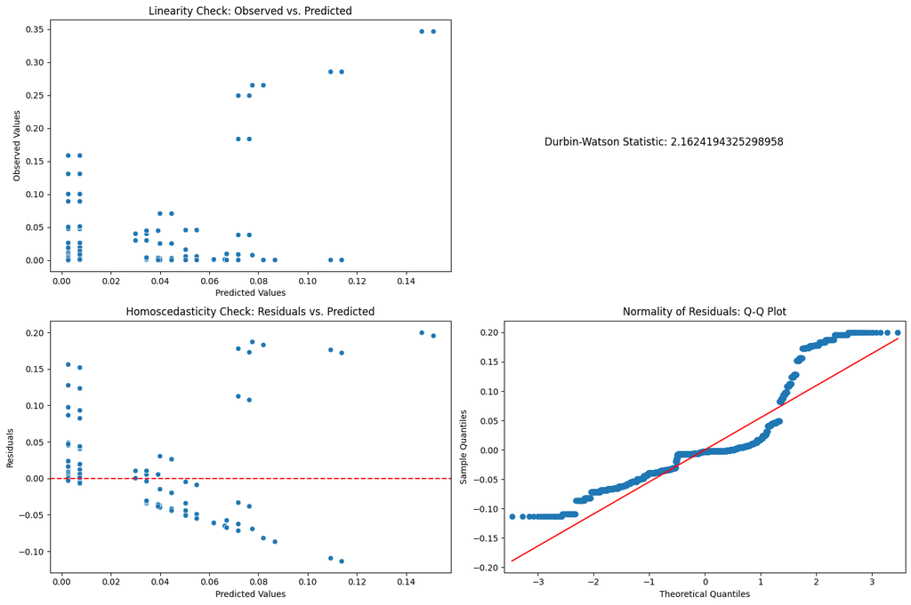

```
(0.79994797706604, 0.0, 2.1624194325298958)
```

```python
# Selecting a few key independent variables for simplicity
# Here, we arbitrarily choose a few columns. For a comprehensive analysis, more rigorous feature selection should be performed.
independent_vars = ['ageCount', 'sexCount', 'dyspnea_in_prior_year', 'rheumatoid_arthritis_in_prior_year', 'seizure_in_prior_year', 'sepsis_in_prior_year']
X = log_transformed_data[independent_vars]
y = log_transformed_data['predicted_risk_of_dementia']

# Adding a constant to the model (the "intercept")
X = sm.add_constant(X)

# Fitting the OLS model
model = sm.OLS(y, X).fit()

# Residuals
residuals = model.resid

# Checking assumptions
fig, axes = plt.subplots(2, 2, figsize=(15, 10))

# Linearity check: Scatter plot of observed vs. predicted values
predicted = model.predict(X)
sns.scatterplot(x=predicted, y=y, ax=axes[0, 0])
axes[0, 0].set_title("Linearity Check: Observed vs. Predicted")
axes[0, 0].set_xlabel("Predicted Values")
axes[0, 0].set_ylabel("Observed Values")

# Independence check: Durbin-Watson Test
# Values of the test statistic close to 2 suggest independence
durbin_watson_stat = sm.stats.durbin_watson(residuals)
axes[0, 1].text(0.1, 0.5, f'Durbin-Watson Statistic: {durbin_watson_stat}', fontsize=12)
axes[0, 1].axis('off')

# Homoscedasticity check: Residuals vs. Predicted values
sns.scatterplot(x=predicted, y=residuals, ax=axes[1, 0])
axes[1, 0].set_title("Homoscedasticity Check: Residuals vs. Predicted")
axes[1, 0].set_xlabel("Predicted Values")
axes[1, 0].set_ylabel("Residuals")
axes[1, 0].axhline(y=0, color='r', linestyle='--')

# Normality of residuals: Q-Q plot
sm.qqplot(residuals, line='s', ax=axes[1, 1])
axes[1, 1].set_title("Normality of Residuals: Q-Q Plot")

plt.tight_layout()
plt.show()

# Shapiro-Wilk normality test on residuals
shapiro_test = stats.shapiro(residuals)
shapiro_test_stat, shapiro_p_value = shapiro_test

shapiro_test_stat, shapiro_p_value, durbin_watson_stat
```

The dataset does not fully meet the OLS assumptions, especially in terms of linearity, homoscedasticity, and normality of residuals.

### Splitting the Dataset

```python
# Splitting the dataset into training and testing sets
# We will use 80% of the data for training and 20% for testing
X_train, X_test, y_train, y_test = train_test_split(X, y, test_size=0.2, random_state=42)

# Verifying the size of the splits
train_size = X_train.shape[0]
test_size = X_test.shape[0]

train_size, test_size
```

```
(3040, 760)
```

### Resampling

```python
# Applying k-fold cross-validation with k=5
k = 5

# Initialize the linear regression model for cross-validation
lin_reg_cv = LinearRegression()

# Applying k-fold cross-validation
cv_scores = cross_val_score(lin_reg_cv, X_train, y_train, cv=k)

# Average score from cross-validation
cv_average_score = np.mean(cv_scores)

cv_scores, cv_average_score
```

```
(array([0.2245829 , 0.33101221, 0.21389407, 0.15967072, 0.26013883]),
 0.23785974732665865)
```

A mean score of around 0.238 suggests a moderate level of predictive accuracy, while the standard deviation of 0.057 indicates some variation in the model's performance across different folds.

```python
# Building an OLS regression model using the training data
ols_model_build = sm.OLS(y_train, X_train).fit()

# Summary of the model
ols_model_build_summary = ols_model_build.summary()
ols_model_build_summary
```

OLS Regression Results

| Dep. Variable: | predicted_risk_of_dementia | R-squared: | 0.254 |
| --- | --- | --- | --- |
| Model: | OLS | Adj. R-squared: | 0.252 |
| Method: | Least Squares | F-statistic: | 171.8 |
| Date: | Sun, 10 Dec 2023 | Prob (F-statistic): | 1.38e-188 |
| Time: | 16:56:36 | Log-Likelihood: | 4473.4 |
| No. Observations: | 3040 | AIC: | -8933. |
| Df Residuals: | 3033 | BIC: | -8891. |
| Df Model: | 6 |  |  |
| Covariance Type: | nonrobust |  |  |

|  | coef | std err | t | P>\|t\| | [0.025 | 0.975] |
| --- | --- | --- | --- | --- | --- | --- |
| const | 0.0073 | 0.002 | 4.387 | 0.000 | 0.004 | 0.011 |
| ageCount | -0.0038 | 0.007 | -0.574 | 0.566 | -0.017 | 0.009 |
| sexCount | -0.0069 | 0.003 | -2.353 | 0.019 | -0.013 | -0.001 |
| dyspnea_in_prior_year | 0.0440 | 0.005 | 8.926 | 0.000 | 0.034 | 0.054 |
| rheumatoid_arthritis_in_prior_year | 0.0709 | 0.005 | 15.301 | 0.000 | 0.062 | 0.080 |
| seizure_in_prior_year | 0.0498 | 0.004 | 12.842 | 0.000 | 0.042 | 0.057 |
| sepsis_in_prior_year | 0.0563 | 0.004 | 13.175 | 0.000 | 0.048 | 0.065 |

| Omnibus: | 924.367 | Durbin-Watson: | 2.016 |
| --- | --- | --- | --- |
| Prob(Omnibus): | 0.000 | Jarque-Bera (JB): | 2663.682 |
| Skew: | 1.586 | Prob(JB): | 0.00 |
| Kurtosis: | 6.312 | Cond. No. | 7.15 |

Notes:  
[1] Standard Errors assume that the covariance matrix of the errors is correctly specified.

- R-squared: 0.254, indicating that about 25.4% of the variance in the dependent variable is explained by the model.
- Adjusted R-squared: 0.252, which adjusts the R-squared value for the number of predictors in the model.
- F-statistic: 171.8, with a very low Prob (F-statistic), suggesting that the model is statistically significant.
- Coefficients: The coefficients for each independent variable indicate the magnitude and direction of the relationship with the dependent variable. Notably, rheumatoid_arthritis_in_prior_year has a positive coefficient of 0.0709.
- P-values: P-values for each coefficient test the null hypothesis that the coefficient is zero (no effect). A low p-value (< 0.05) suggests rejecting the null hypothesis. Most variables have significant p-values except for age_count.
- Omnibus, Prob(Omnibus): Tests the skewness and kurtosis of the residuals. A low p-value here suggests non-normality of residuals.
- Durbin-Watson: Close to 2.0, suggesting no autocorrelation in the residuals.
- Jarque-Bera (JB), Prob(JB): Tests the normality of residuals. A significant JB (low p-value) indicates the residuals are not normally distributed.
- Skew and Kurtosis: Indicate the asymmetry and tail heaviness of the residuals distribution compared to a normal distribution.

```python
# Extracting p-values and other statistics for diagnostics
p_values_diagnostics = ols_model_build.pvalues
coefficients_diagnostics = ols_model_build.params
standard_errors_diagnostics = ols_model_build.bse
t_values_diagnostics = ols_model_build.tvalues

# Creating a DataFrame for model diagnostics
model_diagnostics_data = {
    'Coefficient': coefficients_diagnostics,
    'Standard Error': standard_errors_diagnostics,
    't-value': t_values_diagnostics,
    'p-value': p_values_diagnostics
}
model_diagnostics_df = pd.DataFrame(model_diagnostics_data)
model_diagnostics_df
```

|  | Coefficient | Standard Error | t-value | p-value |
| --- | --- | --- | --- | --- |
| const | 0.007307 | 0.001666 | 4.386678 | 1.190158e-05 |
| ageCount | -0.003764 | 0.006557 | -0.573958 | 5.660391e-01 |
| sexCount | -0.006887 | 0.002928 | -2.352599 | 1.870629e-02 |
| dyspnea_in_prior_year | 0.043963 | 0.004925 | 8.925723 | 7.500811e-19 |
| rheumatoid_arthritis_in_prior_year | 0.070914 | 0.004635 | 15.300585 | 5.782345e-51 |
| seizure_in_prior_year | 0.049835 | 0.003881 | 12.842171 | 8.505421e-37 |
| sepsis_in_prior_year | 0.056253 | 0.004270 | 13.175381 | 1.368578e-38 |

Key Observations:

- The variables dyspnea_in_prior_year, rheumatoid_arthritis_in_prior_year, seizure_in_prior_year, and sepsis_in_prior_year have significant p-values, suggesting they are statistically significant predictors of predicted_risk_of_dementia.
- age_count is not a significant predictor in this model.

### Evaluate Model Performance

- R-squared (R²): 0.099
  - This metric measures the proportion of variance in the dependent variable that is predictable from the independent variables. An R² of 0.099 suggests that the model explains approximately 9.9% of the variability in the test data.
- Root Mean Squared Error (RMSE): 0.0512
  - RMSE is a measure of the differences between the predicted values and the actual values. A lower RMSE value indicates better fit. In this context, the RMSE is relatively low, which is good, but it should be interpreted relative to the scale of the dependent variable.
- Mean Absolute Error (MAE): 0.0333
  - MAE measures the average magnitude of the errors in a set of predictions, without considering their direction. A lower MAE also indicates a better fit. Similar to RMSE, the MAE should be interpreted in the context of the scale of the dependent variable.

```python
# Predicting the outcomes on the test set
y_pred_performance = ols_model_build.predict(X_test)

# Calculating performance metrics
r_squared_performance = r2_score(y_test, y_pred_performance)
rmse_performance = mean_squared_error(y_test, y_pred_performance, squared=False)
mae_performance = mean_absolute_error(y_test, y_pred_performance)

r_squared_performance, rmse_performance, mae_performance
```

```
(0.09909636600720073, 0.051225223692530505, 0.03334801266218313)
```

## Alternative Regressions

### Random Forest Regression:

- A non-linear, tree-based model that can capture complex relationships in the data.
- Useful for datasets with a mix of numerical and categorical variables, and when the relationship between the variables and the response is not assumed to be linear.
- Provides important features based on the reduction of the mean squared error (MSE).

```python
# Random Forest Regression
rf = RandomForestRegressor(random_state=42)
rf.fit(X_train, y_train)
y_pred_rf = rf.predict(X_test)

# Performance metrics for Random Forest Regression
r_squared_rf = r2_score(y_test, y_pred_rf)
rmse_rf = mean_squared_error(y_test, y_pred_rf, squared=False)
mae_rf = mean_absolute_error(y_test, y_pred_rf)

r_squared_rf, rmse_rf, mae_rf
```

```
(0.49783187243497284, 0.038244524581484515, 0.020227158861620645)
```

### Logistic Regression

- Logistic Regression is ideal for binary categorization of a continuous target variable, such as converting a continuous dementia risk score into a high-risk vs. low-risk classification, which can be crucial for actionable medical decisions.
- It offers not just classifications but also the probabilities of these outcomes, providing a nuanced understanding of risk levels, which is particularly valuable in healthcare settings for patient risk assessment.
- The model's simplicity and the interpretability of its coefficients as odds ratios make it a good choice for scenarios where understanding the direct impact of predictors on outcomes is essential, such as in epidemiological studies.

```python
# Since Logistic Regression is used for classification, we need to convert the target variable to a categorical type
# Here, we will binarize the target variable based on its median
median_target = y.median()
y_binarized = (y > median_target).astype(int)

# Splitting the binarized dataset
X_train_lr, X_test_lr, y_train_lr, y_test_lr = train_test_split(X, y_binarized, test_size=0.2, random_state=42)

# Logistic Regression Model
logistic_model = LogisticRegression(max_iter=1000, random_state=42)
logistic_model.fit(X_train_lr, y_train_lr)
y_pred_logistic = logistic_model.predict(X_test_lr)

# Performance metrics for Logistic Regression
from sklearn.metrics import accuracy_score, precision_score, recall_score, f1_score

accuracy_lr = accuracy_score(y_test_lr, y_pred_logistic)
precision_lr = precision_score(y_test_lr, y_pred_logistic)
recall_lr = recall_score(y_test_lr, y_pred_logistic)
f1_lr = f1_score(y_test_lr, y_pred_logistic)

accuracy_lr, precision_lr, recall_lr, f1_lr
```

```
(0.5131578947368421,
 0.5282258064516129,
 0.3411458333333333,
 0.4145569620253164)
```

### Interpretation:

- Random Forest Regression
  - R-squared: 0.498 - Indicates the model explains about 49.8% of the variance in the data.
  - RMSE (Root Mean Squared Error): 0.0382 - A lower RMSE indicates a better fit of the model to the data.
  - MAE (Mean Absolute Error): 0.0202 - Represents the average absolute difference between the observed actual outcomes and the predictions by the model.
- Logistic Regression
  - Accuracy: 51.32% - The proportion of total predictions (high-risk vs low-risk of dementia) that were correct.
  - Precision: 52.82% - Indicates the proportion of positive identifications that were actually correct.
  - Recall: 34.11% - Reflects the proportion of actual positives that were correctly identified.
  - F1 Score: 0.415 - A harmonic mean of precision and recall, useful for unbalanced classes.

### Hyperparameter Tuning

Hyperparameter tuning is a crucial step in optimizing machine learning models for the best performance. For both Random Forest and Logistic Regression models, we'll use cross-validation techniques to find optimal hyperparameters.

#### Random Forest Regression Hyperparameter Tuning

```python
# Define the parameter grid for Random Forest
rf_param_grid = {
    'n_estimators': [100, 200, 300],
    'max_depth': [None, 10, 20, 30],
    'min_samples_split': [2, 5, 10],
    'min_samples_leaf': [1, 2, 4]
}

# Initialize the GridSearchCV object for Random Forest
rf_grid_search = GridSearchCV(estimator=RandomForestRegressor(random_state=42),
                              param_grid=rf_param_grid,
                              cv=5,  # 5-fold cross-validation
                              scoring='neg_mean_squared_error',  # You can choose a different scorer
                              verbose=1)

# Fit the grid search to the data
rf_grid_search.fit(X_train, y_train)

# Get the best parameters and their corresponding score
best_params_rf = rf_grid_search.best_params_
best_score_rf = rf_grid_search.best_score_
```

```
Fitting 5 folds for each of 108 candidates, totalling 540 fits
```

#### Logistic Regression Hyperparameter Tuning

```python
# Define the parameter grid for Logistic Regression
logistic_param_grid = {
    'C': np.logspace(-4, 4, 20),  # Regularization strength
    'penalty': ['l1', 'l2'],  # Regularization type
    'solver': ['liblinear']  # Algorithm for optimization problem
}

# Initialize the GridSearchCV object for Logistic Regression
logistic_grid_search = GridSearchCV(estimator=LogisticRegression(max_iter=1000, random_state=42),
                                    param_grid=logistic_param_grid,
                                    cv=5,  # 5-fold cross-validation
                                    scoring='accuracy',  # You can choose a different scorer
                                    verbose=1)

# Fit the grid search to the binarized data
logistic_grid_search.fit(X_train_lr, y_train_lr)

# Get the best parameters and their corresponding score
best_params_logistic = logistic_grid_search.best_params_
best_score_logistic = logistic_grid_search.best_score_
```

```
Fitting 5 folds for each of 40 candidates, totalling 200 fits
```

### Model Evaluation

#### Random Forest Regression - Tuned Model Evaluation

```python
# Retrain the Random Forest model with the best parameters
best_params_rf = rf_grid_search.best_params_
rf_tuned = RandomForestRegressor(**best_params_rf, random_state=42)
rf_tuned.fit(X_train, y_train)

# Predict and evaluate the tuned Random Forest model
y_pred_rf_tuned = rf_tuned.predict(X_test)
r_squared_rf_tuned = r2_score(y_test, y_pred_rf_tuned)
rmse_rf_tuned = mean_squared_error(y_test, y_pred_rf_tuned, squared=False)
mae_rf_tuned = mean_absolute_error(y_test, y_pred_rf_tuned)

# Print the performance metrics
print("Tuned Random Forest - R-squared:", r_squared_rf_tuned)
print("Tuned Random Forest - RMSE:", rmse_rf_tuned)
print("Tuned Random Forest - MAE:", mae_rf_tuned)
```

```
Tuned Random Forest - R-squared: 0.5263347501740129
Tuned Random Forest - RMSE: 0.037143297452787424
Tuned Random Forest - MAE: 0.019959568877431704
```

#### Logistic Regression - Tuned Model Evaluation

```python
# Retrain the Logistic Regression model with the best parameters
best_params_logistic = logistic_grid_search.best_params_
logistic_tuned = LogisticRegression(**best_params_logistic, max_iter=1000, random_state=42)
logistic_tuned.fit(X_train_lr, y_train_lr)

# Predict and evaluate the tuned Logistic Regression model
y_pred_logistic_tuned = logistic_tuned.predict(X_test_lr)
accuracy_lr_tuned = accuracy_score(y_test_lr, y_pred_logistic_tuned)
precision_lr_tuned = precision_score(y_test_lr, y_pred_logistic_tuned)
recall_lr_tuned = recall_score(y_test_lr, y_pred_logistic_tuned)
f1_lr_tuned = f1_score(y_test_lr, y_pred_logistic_tuned)

# Print the performance metrics
print("Tuned Logistic Regression - Accuracy:", accuracy_lr_tuned)
print("Tuned Logistic Regression - Precision:", precision_lr_tuned)
print("Tuned Logistic Regression - Recall:", recall_lr_tuned)
print("Tuned Logistic Regression - F1 Score:", f1_lr_tuned)
```

```
Tuned Logistic Regression - Accuracy: 0.5486842105263158
Tuned Logistic Regression - Precision: 0.6120218579234973
Tuned Logistic Regression - Recall: 0.2916666666666667
Tuned Logistic Regression - F1 Score: 0.39506172839506176
```

```python
# Interpreting the coefficients of the Logistic Regression model
coefficients = pd.DataFrame({"Feature": X_train_lr.columns, "Coefficient": logistic_tuned.coef_[0]})
print(coefficients)
```

```
                              Feature  Coefficient
0                               const    -0.049342
1                            ageCount     0.000000
2                            sexCount     0.000000
3               dyspnea_in_prior_year     0.358252
4  rheumatoid_arthritis_in_prior_year     0.005470
5               seizure_in_prior_year     0.000000
6                sepsis_in_prior_year     0.319160
```

### Conclusion

- Random Forest Regression:
  - Improved Performance: The R-squared value increased to 0.526, indicating that the tuned model now explains approximately 52.6% of the variance in the data, which is an improvement from the previous value of 0.498.
  - Reduced Error Metrics: Both the RMSE and MAE have decreased, signifying a better fit of the model. Specifically, the RMSE reduced from 0.0382 to 0.0371, and the MAE from 0.0202 to 0.0200, indicating more accurate predictions.
- Logistic Regression:
  - Moderate Accuracy: The accuracy of the tuned model is approximately 54.9%, an improvement from the initial 51.3%. This suggests that the model correctly predicts the high-risk vs. low-risk dementia classification over half the time.
  - Precision and Recall: The precision improved significantly to 61.2%, indicating a higher rate of true positive predictions among all positive predictions. However, the recall is still low at 29.2%, meaning the model misses a substantial number of actual high-risk cases.
  - F1 Score: An F1 score of 0.395 shows a balance between precision and recall but also indicates room for improvement.

The Random Forest model shows a strong ability to predict the continuous risk score, while the Logistic Regression model, despite being moderate in accuracy, highlights key factors in dementia risk categorization.